# King County House Sales

Elena Kargopiltsev

1/17/2021

#1. Used the read.csv() function to read the data into R. Called the loaded data House. Made sure that the working directory was set to the correct location for the data. If not, use the setwd() function to change the working directory to the right location. Used the attach() function to attach House to the R search path.

```r
House=read.csv("kc house sales.csv")
attach(House)
```

#2. Used the summary() function to obtain a numerical summary of the variables in the data set.

```r
summary(House)
```

```
##      date               price            bedrooms        bathrooms
##  Length:21613       Min.   :  75000   Min.   : 0.000   Min.   :0.000
##  Class :character   1st Qu.: 321950   1st Qu.: 3.000   1st Qu.:1.750
##  Mode  :character   Median : 450000   Median : 3.000   Median :2.250
##                     Mean   : 540182   Mean   : 3.371   Mean   :2.115
##                     3rd Qu.: 645000   3rd Qu.: 4.000   3rd Qu.:2.500
##                     Max.   :7700000   Max.   :33.000   Max.   :8.000
##   sqft_living       sqft_lot           floors        waterfront
##  Min.   :  290   Min.   :    520   Min.   :1.000   Min.   :0.000000
##  1st Qu.: 1427   1st Qu.:   5040   1st Qu.:1.000   1st Qu.:0.000000
##  Median : 1910   Median :   7618   Median :1.500   Median :0.000000
##  Mean   : 2080   Mean   :  15107   Mean   :1.494   Mean   :0.007542
##  3rd Qu.: 2550   3rd Qu.:  10688   3rd Qu.:2.000   3rd Qu.:0.000000
##  Max.   :13540   Max.   :1651359   Max.   :3.500   Max.   :1.000000
##       view          condition         grade          sqft_above
##  Min.   :0.0000   Min.   :1.000   Min.   : 1.000   Min.   : 290
##  1st Qu.:0.0000   1st Qu.:3.000   1st Qu.: 7.000   1st Qu.:1190
##  Median :0.0000   Median :3.000   Median : 7.000   Median :1560
##  Mean   :0.2343   Mean   :3.409   Mean   : 7.657   Mean   :1788
##  3rd Qu.:0.0000   3rd Qu.:4.000   3rd Qu.: 8.000   3rd Qu.:2210
##  Max.   :4.0000   Max.   :5.000   Max.   :13.000   Max.   :9410
##  sqft_basement       yr_built     yr_renovated       zipcode
##  Min.   :   0.0   Min.   :1900   Min.   :   0.0   Min.   :98001
##  1st Qu.:   0.0   1st Qu.:1951   1st Qu.:   0.0   1st Qu.:98033
##  Median :   0.0   Median :1975   Median :   0.0   Median :98065
##  Mean   : 291.5   Mean   :1971   Mean   :  84.4   Mean   :98078
##  3rd Qu.: 560.0   3rd Qu.:1997   3rd Qu.:   0.0   3rd Qu.:98118
##  Max.   :4820.0   Max.   :2015   Max.   :2015.0   Max.   :98199
##       lat             long        sqft_living15    sqft_lot15
##  Min.   :47.16   Min.   :-122.5   Min.   : 399   Min.   :   651
##  1st Qu.:47.47   1st Qu.:-122.3   1st Qu.:1490   1st Qu.:  5100
##  Median :47.57   Median :-122.2   Median :1840   Median :  7620
##  Mean   :47.56   Mean   :-122.2   Mean   :1987   Mean   : 12768
##  3rd Qu.:47.68   3rd Qu.:-122.1   3rd Qu.:2360   3rd Qu.: 10083
##  Max.   :47.78   Max.   :-121.3   Max.   :6210   Max.   :871200
```

#3.Among the variables, the date was treated as a categorical variable in the numerical summary. Converted it to dates using the as. Date() function. In the function, the upper case Y means the first 4 digits represent the year, while lower case m and d mean the next 2 digits each represent month and day, respectively.

```r
date=as.Date(date,format="%Y%m%d")
```

#4.Waterfront, view, and zipcode variables were categorical; however, they were treated as numerical variables in the numerical summary. Converted them to categorical variables using the as.factor() function

```r
view=as.factor(view)
waterfront=as.factor(waterfront)
zipcode=as.factor(zipcode)
```

#5.Obtained a numerical summary of the data set one more time using summary(House).

```r
summary(House)
```

```
##      date               price            bedrooms        bathrooms
##  Length:21613       Min.   :  75000   Min.   : 0.000   Min.   :0.000
##  Class :character   1st Qu.: 321950   1st Qu.: 3.000   1st Qu.:1.750
##  Mode  :character   Median : 450000   Median : 3.000   Median :2.250
##                     Mean   : 540182   Mean   : 3.371   Mean   :2.115
##                     3rd Qu.: 645000   3rd Qu.: 4.000   3rd Qu.:2.500
##                     Max.   :7700000   Max.   :33.000   Max.   :8.000
##   sqft_living       sqft_lot           floors        waterfront
##  Min.   :  290   Min.   :    520   Min.   :1.000   Min.   :0.000000
##  1st Qu.: 1427   1st Qu.:   5040   1st Qu.:1.000   1st Qu.:0.000000
##  Median : 1910   Median :   7618   Median :1.500   Median :0.000000
##  Mean   : 2080   Mean   :  15107   Mean   :1.494   Mean   :0.007542
##  3rd Qu.: 2550   3rd Qu.:  10688   3rd Qu.:2.000   3rd Qu.:0.000000
##  Max.   :13540   Max.   :1651359   Max.   :3.500   Max.   :1.000000
##       view          condition         grade          sqft_above
##  Min.   :0.0000   Min.   :1.000   Min.   : 1.000   Min.   : 290
##  1st Qu.:0.0000   1st Qu.:3.000   1st Qu.: 7.000   1st Qu.:1190
##  Median :0.0000   Median :3.000   Median : 7.000   Median :1560
##  Mean   :0.2343   Mean   :3.409   Mean   : 7.657   Mean   :1788
##  3rd Qu.:0.0000   3rd Qu.:4.000   3rd Qu.: 8.000   3rd Qu.:2210
##  Max.   :4.0000   Max.   :5.000   Max.   :13.000   Max.   :9410
##  sqft_basement       yr_built     yr_renovated       zipcode
##  Min.   :   0.0   Min.   :1900   Min.   :   0.0   Min.   :98001
##  1st Qu.:   0.0   1st Qu.:1951   1st Qu.:   0.0   1st Qu.:98033
##  Median :   0.0   Median :1975   Median :   0.0   Median :98065
##  Mean   : 291.5   Mean   :1971   Mean   :  84.4   Mean   :98078
##  3rd Qu.: 560.0   3rd Qu.:1997   3rd Qu.:   0.0   3rd Qu.:98118
##  Max.   :4820.0   Max.   :2015   Max.   :2015.0   Max.   :98199
##       lat             long        sqft_living15    sqft_lot15
##  Min.   :47.16   Min.   :-122.5   Min.   : 399   Min.   :   651
##  1st Qu.:47.47   1st Qu.:-122.3   1st Qu.:1490   1st Qu.:  5100
##  Median :47.57   Median :-122.2   Median :1840   Median :  7620
##  Mean   :47.56   Mean   :-122.2   Mean   :1987   Mean   : 12768
##  3rd Qu.:47.68   3rd Qu.:-122.1   3rd Qu.:2360   3rd Qu.: 10083
##  Max.   :47.78   Max.   :-121.3   Max.   :6210   Max.   :871200
```

# As a result, all four variables are still considered numerical.

#6.Obtained a numerical summary of the four variables created in the global environment in question 3 and 4 using summary(data.frame(date, view, waterfront, zipcode)).

```r
summary(data.frame(date,view,waterfront,zipcode))
```

```
##       date            view      waterfront    zipcode
##  Min.   :2014-05-02   0:19489   0:21450    98103  :  602
##  1st Qu.:2014-07-22   1:  332   1:  163    98038  :  590
##  Median :2014-10-16   2:  963              98115  :  583
##  Mean   :2014-10-29   3:  510              98052  :  574
##  3rd Qu.:2015-02-17   4:  319              98117  :  553
##  Max.   :2015-05-27                        98042  :  548
##                                            (Other):18163
```

# At this time variables treated correctly because I used “data.frames”.

#7.Eliminated the four variables in House and add date, view, waterfront, and zip code in the global environment to House. Obtained numerical summary of the variables in-house.

```r
House=data.frame(House[,-c(1,8:9,16)],date,view,waterfront,zipcode)
summary(House)
```

```
##      price            bedrooms        bathrooms      sqft_living
##  Min.   :  75000   Min.   : 0.000   Min.   :0.000   Min.   :  290
##  1st Qu.: 321950   1st Qu.: 3.000   1st Qu.:1.750   1st Qu.: 1427
##  Median : 450000   Median : 3.000   Median :2.250   Median : 1910
##  Mean   : 540182   Mean   : 3.371   Mean   :2.115   Mean   : 2080
##  3rd Qu.: 645000   3rd Qu.: 4.000   3rd Qu.:2.500   3rd Qu.: 2550
##  Max.   :7700000   Max.   :33.000   Max.   :8.000   Max.   :13540
##
##     sqft_lot           floors        condition         grade
##  Min.   :    520   Min.   :1.000   Min.   :1.000   Min.   : 1.000
##  1st Qu.:   5040   1st Qu.:1.000   1st Qu.:3.000   1st Qu.: 7.000
##  Median :   7618   Median :1.500   Median :3.000   Median : 7.000
##  Mean   :  15107   Mean   :1.494   Mean   :3.409   Mean   : 7.657
##  3rd Qu.:  10688   3rd Qu.:2.000   3rd Qu.:4.000   3rd Qu.: 8.000
##  Max.   :1651359   Max.   :3.500   Max.   :5.000   Max.   :13.000
##
##    sqft_above   sqft_basement       yr_built     yr_renovated
##  Min.   : 290   Min.   :   0.0   Min.   :1900   Min.   :   0.0
##  1st Qu.:1190   1st Qu.:   0.0   1st Qu.:1951   1st Qu.:   0.0
##  Median :1560   Median :   0.0   Median :1975   Median :   0.0
##  Mean   :1788   Mean   : 291.5   Mean   :1971   Mean   :  84.4
##  3rd Qu.:2210   3rd Qu.: 560.0   3rd Qu.:1997   3rd Qu.:   0.0
##  Max.   :9410   Max.   :4820.0   Max.   :2015   Max.   :2015.0
##
##       lat             long        sqft_living15    sqft_lot15
##  Min.   :47.16   Min.   :-122.5   Min.   : 399   Min.   :   651
##  1st Qu.:47.47   1st Qu.:-122.3   1st Qu.:1490   1st Qu.:  5100
##  Median :47.57   Median :-122.2   Median :1840   Median :  7620
##  Mean   :47.56   Mean   :-122.2   Mean   :1987   Mean   : 12768
##  3rd Qu.:47.68   3rd Qu.:-122.1   3rd Qu.:2360   3rd Qu.: 10083
##  Max.   :47.78   Max.   :-121.3   Max.   :6210   Max.   :871200
##
##       date            view      waterfront    zipcode
##  Min.   :2014-05-02   0:19489   0:21450    98103  :  602
##  1st Qu.:2014-07-22   1:  332   1:  163    98038  :  590
##  Median :2014-10-16   2:  963              98115  :  583
##  Mean   :2014-10-29   3:  510              98052  :  574
##  3rd Qu.:2015-02-17   4:  319              98117  :  553
##  Max.   :2015-05-27                        98042  :  548
##                                            (Other):18163
```

#8. Used the unique() function to produce different levels of zipcode. To analyze how many levels it has.

```r
unique(zipcode)
```

```
##  [1] 98178 98125 98028 98136 98074 98053 98003 98198 98146 98038 98007 98115
## [13] 98107 98126 98019 98103 98002 98133 98040 98092 98030 98119 98112 98052
## [25] 98027 98117 98058 98001 98056 98166 98023 98070 98148 98105 98042 98008
## [37] 98059 98122 98144 98004 98005 98034 98075 98116 98010 98118 98199 98032
## [49] 98045 98102 98077 98108 98168 98177 98065 98029 98006 98109 98022 98033
## [61] 98155 98024 98011 98031 98106 98072 98188 98014 98055 98039
## 70 Levels: 98001 98002 98003 98004 98005 98006 98007 98008 98010 ... 98199
```

# It has 70 zipcode levels.

#9.Used the pairs() function to obtain a scatter-plot matrix of price, bedrooms, and bathrooms

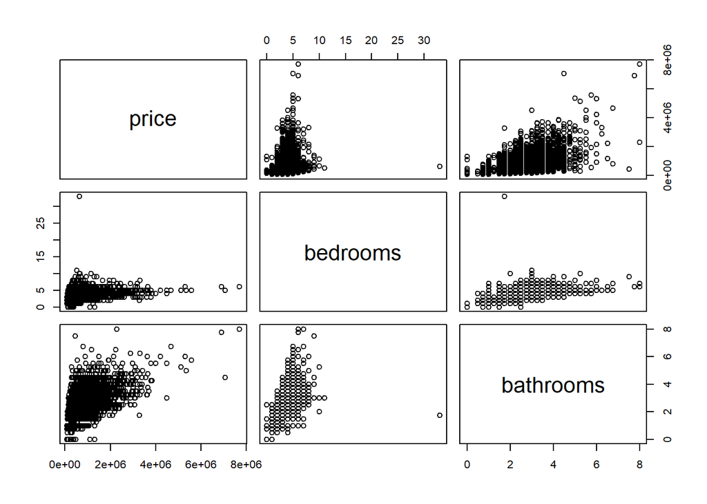

```r
pairs(House[,1:3])
```

#10.Used the table() function to produce a frequency table of bedrooms. Analysing any unusual observations.

```r
table(bedrooms)
```

```
## bedrooms
##    0    1    2    3    4    5    6    7    8    9   10   11   33
##   13  199 2760 9824 6882 1601  272   38   13    6    3    1    1
```

# There are 33 bedrooms in one house.

#11.One house has 33 bedrooms. Printing the observations with more than 30 bedrooms

```r
House[bedrooms>30,]
```

```
##        price bedrooms bathrooms sqft_living sqft_lot floors condition grade
## 15871 640000       33      1.75        1620     6000      1         5     7
##       sqft_above sqft_basement yr_built yr_renovated     lat     long
## 15871       1040           580     1947            0 47.6878 -122.331
##       sqft_living15 sqft_lot15       date view waterfront zipcode
## 15871          1330       4700 2014-06-25    0          0   98103
```

#12. It is obvious that the above observation (observation #15871) was incorrectly recorded since it had 33 bedrooms while its living space was only 1620 sf. Changing the number of bedrooms of this observation to 3 using the following function:

```r
House[15871,2]=3
detach(House)
attach(House)
```

#13. Used the pairs() function to obtain a scatter-plot matrix of price, bedrooms, and bathrooms one more time. Discovered a relationship between the three variables.

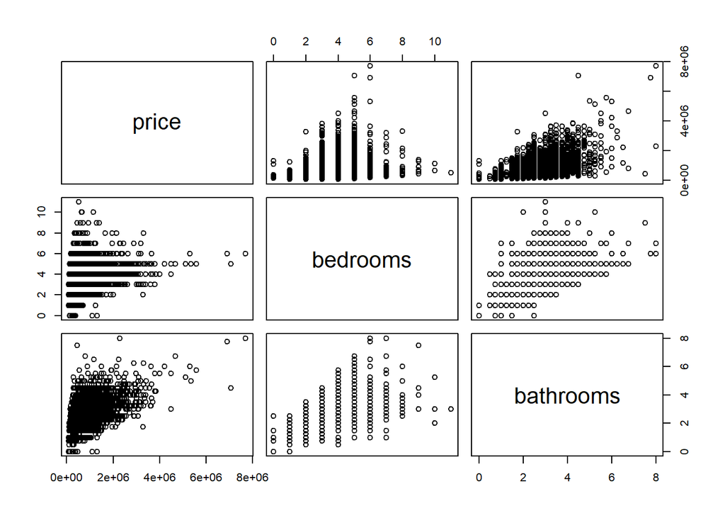

```r
pairs(House[,1:3])
```

## The price of a house increases with the number of bedrooms and bathrooms.

#14.Used the plot() function to produce side-by-side box plots of price for two waterfront categories and five categories of view.

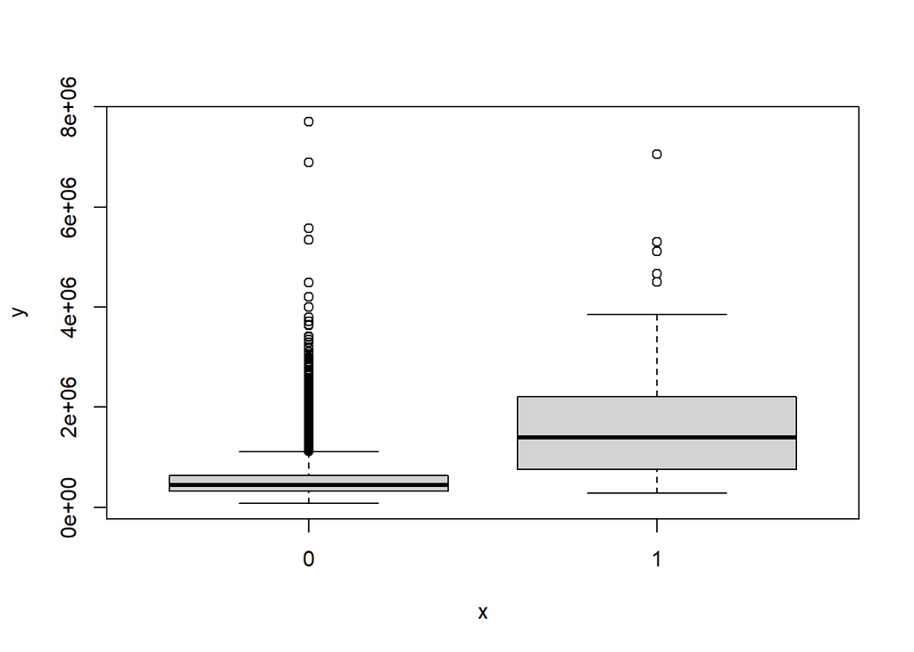

```r
plot(waterfront,price)
```

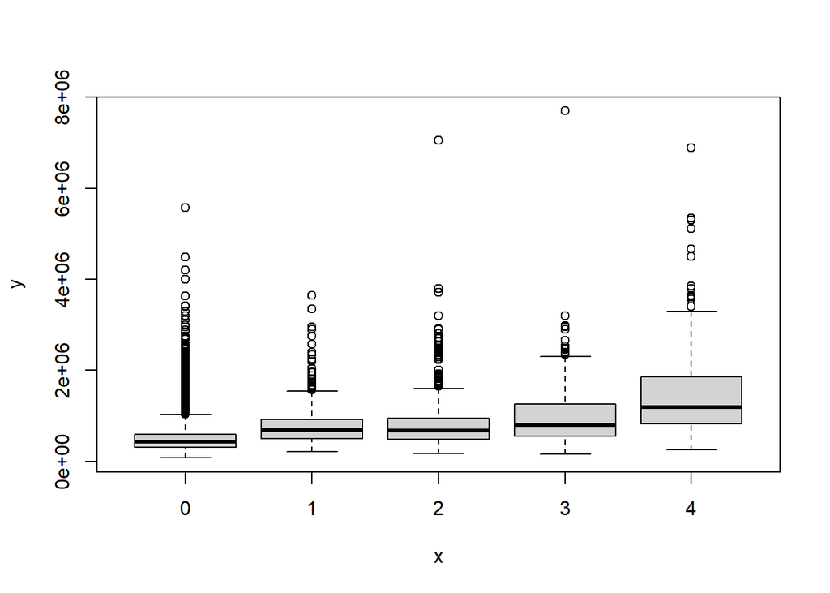

```r
plot(view,price)
```

#15. Used the hist() function to produce histograms of price, sqft_living, and sqft_lot

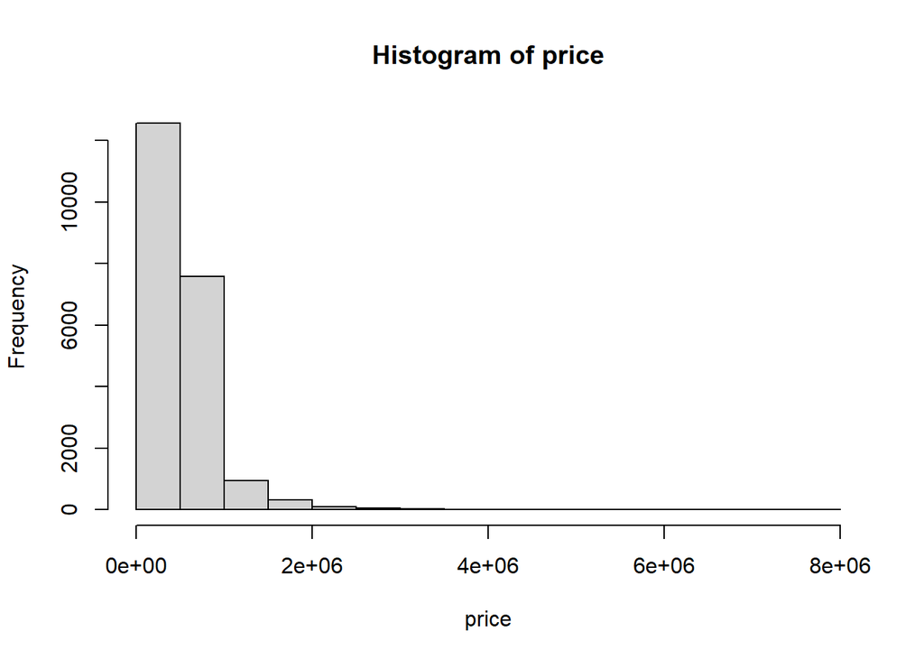

```r
hist(price)
```

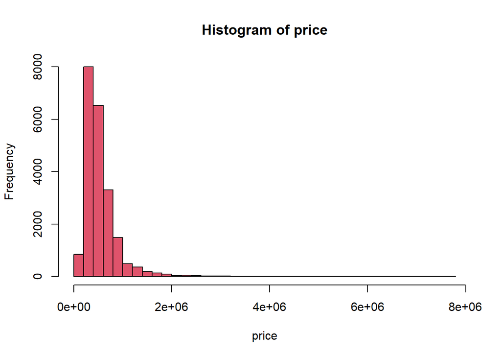

```r
hist(price,breaks=30,col=2)
```

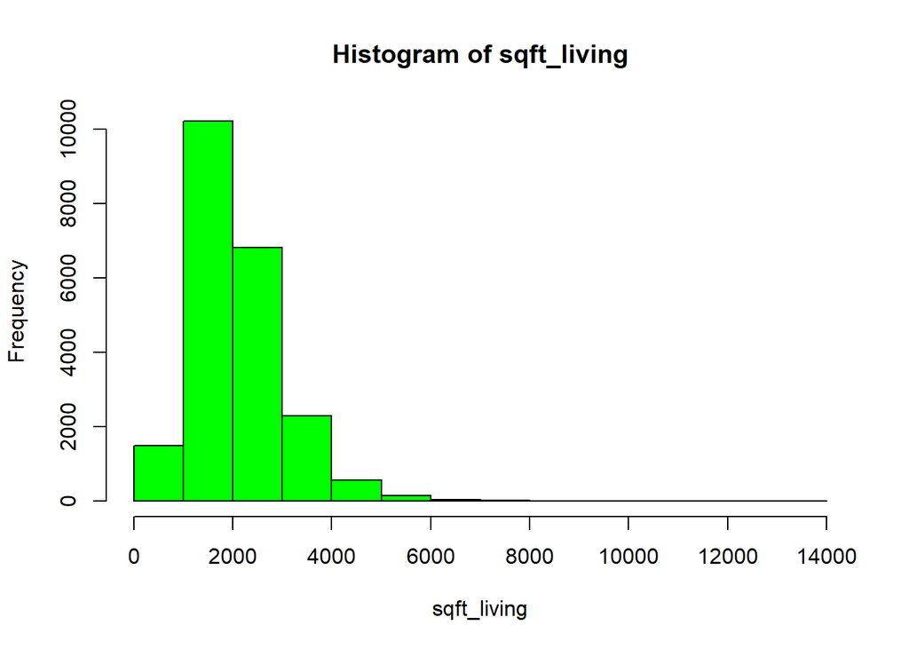

```r
hist(sqft_living,col="green")
```

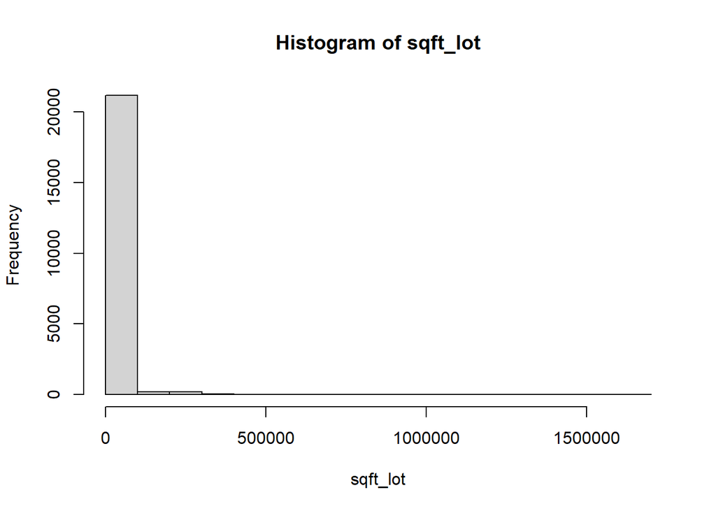

```r
hist(sqft_lot)
```

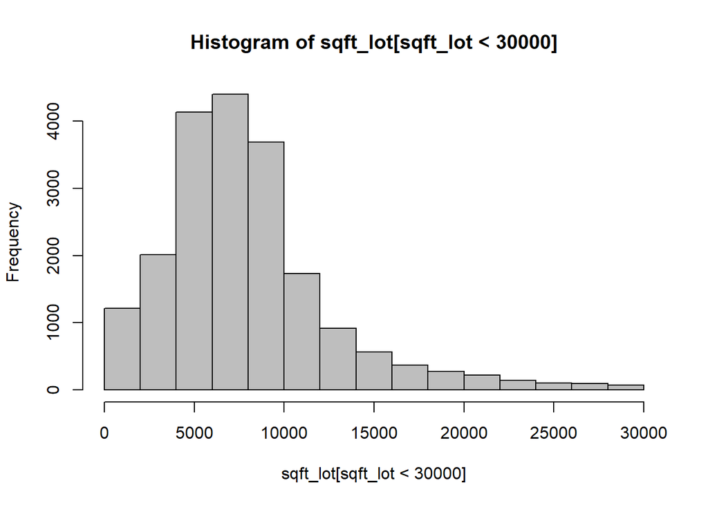

```r
hist(sqft_lot[sqft_lot<30000],col="gray")
```

#16. Used the command par(mfrow=c(2, 2)) or par(mfcol=c(2, 2)) to divide the plots window into four regions and repeat questions 14 and 15. You can modify the arguments to these functions to divide the window in a different way. To return to the original setting, Used the command par(mfrow=c(1, 1)).

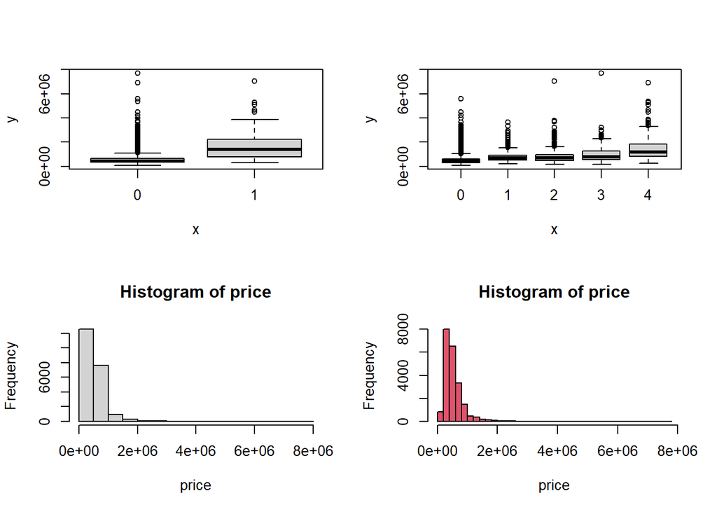

```r
par(mfrow=c(2,2))
plot(waterfront,price)
plot(view,price)
hist(price)
hist(price,breaks=30,col=2)
```

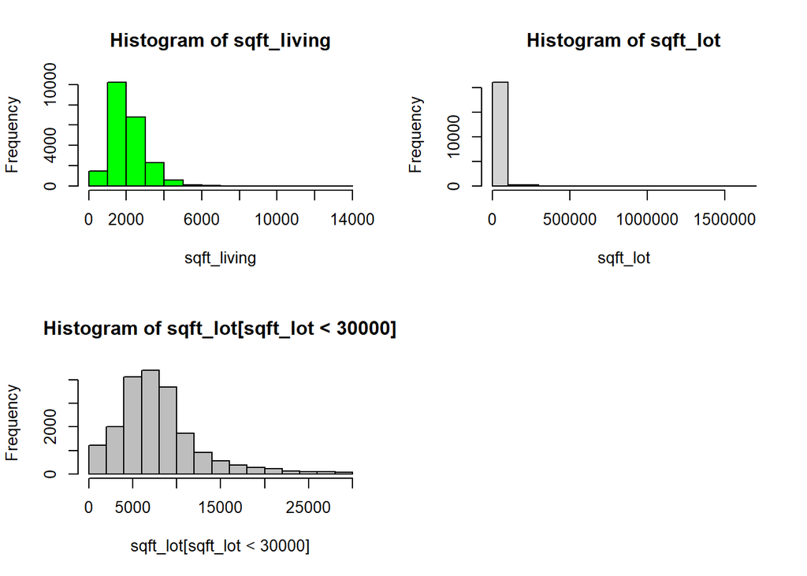

```r
hist(sqft_living,col="green")
hist(sqft_lot)
hist(sqft_lot[sqft_lot<30000],col="gray")
```

#17.Used the sapply() function to obtain the range of all quantitative variables and call the output ranges

```r
ranges=sapply(House[,1:16],range)
```

#18.Outputting the entire matrix of ranges. Printed the largest number of bathrooms in House data using the indies of ranges

```r
ranges
```

```
##        price bedrooms bathrooms sqft_living sqft_lot floors condition grade
## [1,]   75000        0         0         290      520    1.0         1     1
## [2,] 7700000       11         8       13540  1651359    3.5         5    13
##      sqft_above sqft_basement yr_built yr_renovated     lat     long
## [1,]        290             0     1900            0 47.1559 -122.519
## [2,]       9410          4820     2015         2015 47.7776 -121.315
##      sqft_living15 sqft_lot15
## [1,]           399        651
## [2,]          6210     871200
```

```r
ranges[2,]
```

```
##         price      bedrooms     bathrooms   sqft_living      sqft_lot
##  7700000.0000       11.0000        8.0000    13540.0000  1651359.0000
##        floors     condition         grade    sqft_above sqft_basement
##        3.5000        5.0000       13.0000     9410.0000     4820.0000
##      yr_built  yr_renovated           lat          long sqft_living15
##     2015.0000     2015.0000       47.7776     -121.3150     6210.0000
##    sqft_lot15
##   871200.0000
```

#19. Created a new categorical variable, called a mansion, by binning the sqft_living15 variable. All houses are divided into two groups based on whether or not the living space in 2015 exceeds 5,000 SF.

```r
mansion=rep("No",nrow(House))
mansion[sqft_living15>5000]="Yes"
mansion=as.factor(mansion)
```

#20. Founded how many mansions were sold during the period using the summary() function.

```r
summary(mansion)
```

```
##    No   Yes
## 21591    22
```

#21. Used the plot() function to produce side-by-side box-plots of price versus mansion.

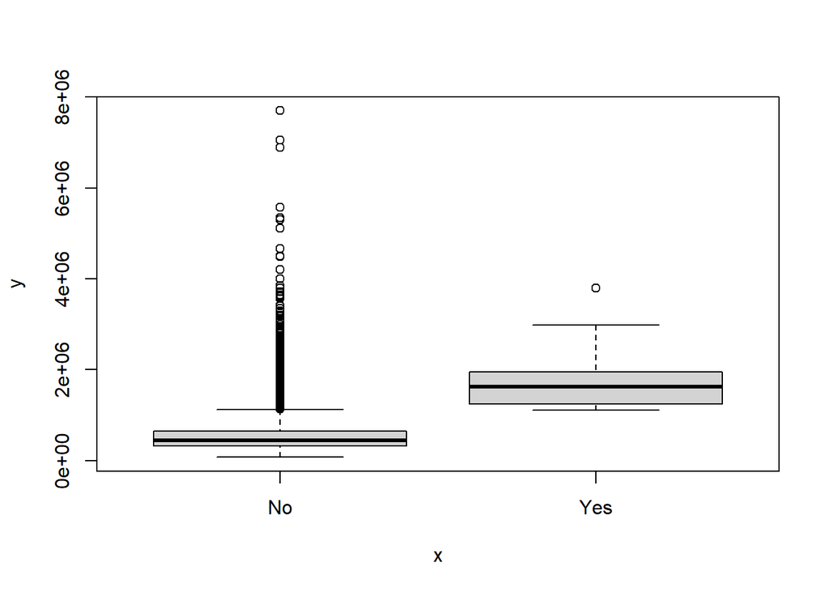

```r
plot(mansion,price)
```

#22.Used the subset() function to create a subset, called House.wf, containing waterfront houses only. Finded the average price of the waterfront houses.

```r
House.wf=subset(House,waterfront==1)
mean(House.wf$price)
```

```
## [1] 1662524
```

#23.Used the subset() function to create a subset, called House.old, containing houses at least 100 years old. Used the dim() function to find the number of houses in House.old.

```r
House.old=subset(House,yr_built<=1920)
dim(House.old)
```

```
## [1] 1549   20
```